# STA-290 HW 1

2024-01-29

From the [IMS Textbook](https://openintro-ims.netlify.app/), do the following exercises:

- Ch 4.8: #4, #5, #6
- Ch 5.10 #1, #2

**Question 1:** For this question, we will use data obtained from the [US Department of Education’s College Scorecard](https://collegescorecard.ed.gov/) which includes information from 2019 on all primarily undergraduate colleges with at least 400 enrolled students.

The link for the data is available at this URL: https://remiller1450.github.io/data/Colleges2019_Complete.csv

- **Part A** Write code to load this data into R as a data.frame named `colleges`
- **Part B** Find the number of observations and variables in this dataset. In one sentence, briefly describe what constitutes an observation in this data
- **Part C** Below we see a plot showing the relationship between `Cost`, a school’s total annual cost of attendance without considering financial aid, and `Salary10yr_median`, the median salary of graduates from the college 10 years after receiving their degree. Use the plot to answer the questions the following questions
  - What type of plot is displayed here?
  - Comment on the **form**, **strength**, and **direction** of the relationship. What do we see? (approximate answers are OK)

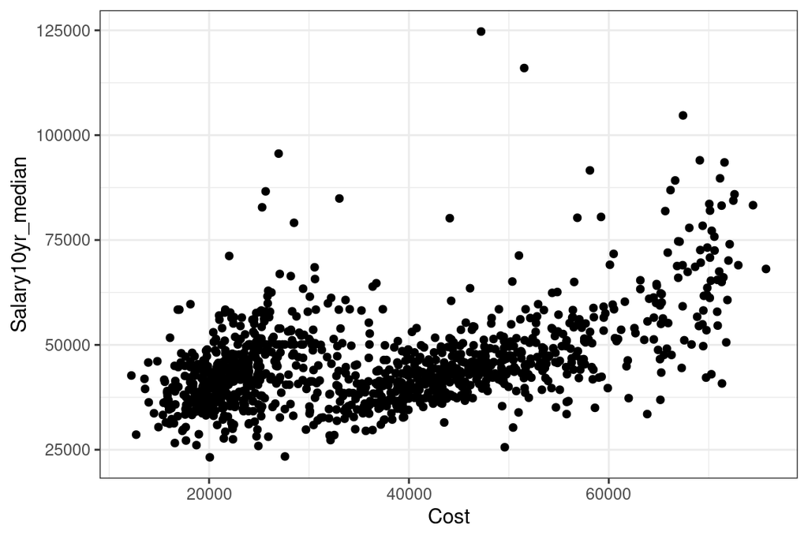

- **Part D** Consider this plot again, now with *color* added to the plot. What kind of variable is represented by the color (categorical/quantitative), and how does adding color change our interpretation of the plot?

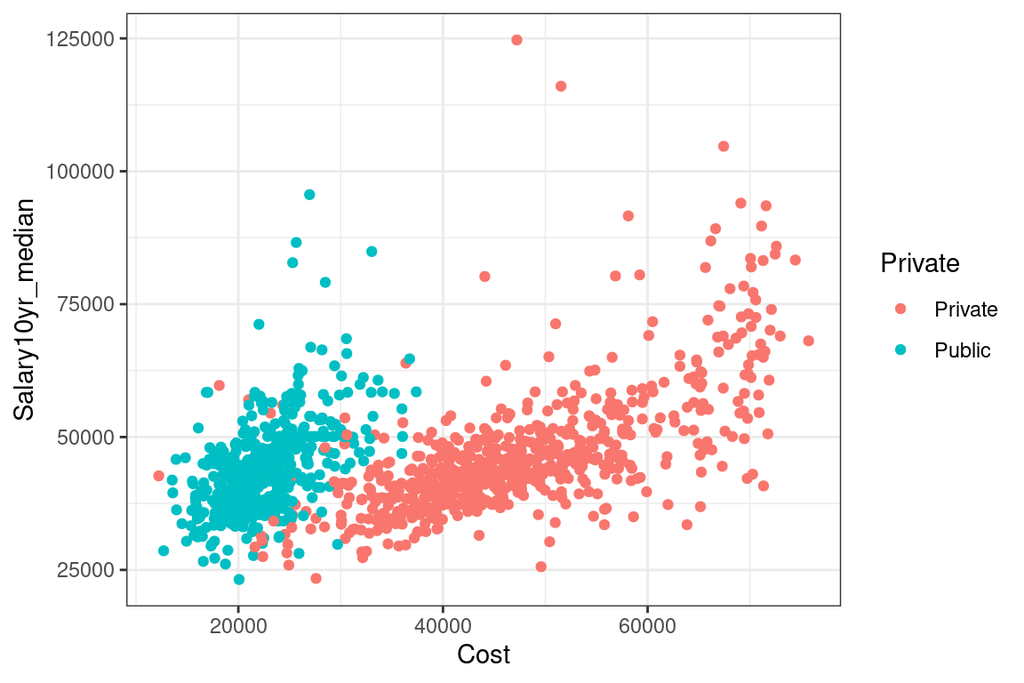